# TEST 1. WIND ENERGY FACILITIES (PORTUGAL)

Evelyn Cruz

2026-08-27

## 1. Introduction

This analysis investigates the spatial distribution of wind energy facilities in mainland Portugal, focusing on installed capacity, elevation, temporal growth, and intersections with Natura 2000 sites. The workflow integrates spatial data, administrative boundaries, a digital elevation model, and protected-area data to characterize the distribution of wind energy infrastructure.

## 2. Packages

```r
library(sf)
library(dplyr)
```

```r
library(ggplot2)
library(terra)
library(leaflet)
library(geodata)
```

## 3. Data Upload and Inspection

The datasets were uploaded to the R environment and inspected before analysis

```r
load("data/adm0_pt.rda")
names(adm0_pt)
```

```
## [1] "geom"
```

```r
load("data/adm1_pt.rda")
names(adm1_pt)
```

```
## [1] "Distrito" "geom"
```

```r
load("data/rn2000.rda")
names(rn2000)
```

```
## [1] "SITE_CODE" "SITE_NAME" "AREA__HA_" "TIPO"      "geometry"
```

```r
load("data/e2p.rda")
names(e2p)
```

```
## [1] "nome"                            "tecnologia"
## [3] "distrito_regiao_autonoma"        "latitude_wgs84_o"
## [5] "longitude_wgs84_o"               "potencia_instalada_mw"
## [7] "estado"                          "ano_de_entrada_em_funcionamento"
```

## 4. Wind Facilities as Spatial Points

Longitude and latitude coordinates were converted to numeric values and used to create point geometries in WGS84 (EPSG:4326)

```r
e2p$longitude_wgs84_o <- as.numeric(gsub(",", ".", e2p$longitude_wgs84_o))
e2p$latitude_wgs84_o <- as.numeric(gsub(",", ".", e2p$latitude_wgs84_o))

e2p_sf <- st_as_sf(e2p,
  coords = c("longitude_wgs84_o",
    "latitude_wgs84_o"), crs = 4326)
```

## 5. CRS Standardization

All spatial datasets were standardized to WGS84 (EPSG:4326)

```r
adm0_pt <- st_transform(adm0_pt, 4326)
adm1_pt <- st_transform(adm1_pt, 4326)
rn2000 <- st_transform(rn2000, 4326)
```

## 6. Geometry Cleaning

Empty geometries were removed and invalid geometries were corrected

```r
e2p_sf <- e2p_sf[!st_is_empty(e2p_sf), ]

adm0_pt <- st_make_valid(adm0_pt)
adm1_pt <- st_make_valid(adm1_pt)
rn2000 <- st_make_valid(rn2000)
```

# Question 1. Map the wind energy facilities in mainland Portugal regarding the country and district borders. Apply the appropriate legend and choose one aggregation level (legend) to wind energy facilities.

## 7. Facilities in Mainland Portugal

Only facilities located within mainland Portugal were retained

```r
e2p_pt <- st_filter(e2p_sf,adm0_pt)
```

## 8. Installed Capacity by District

Installed capacity was converted from character to numeric format

```r
e2p_sf$potencia_instalada_mw <- as.numeric(gsub(",", ".", e2p_sf$potencia_instalada_mw))

e2p_pt <- st_filter(e2p_sf, adm0_pt)

e2p_district <- st_join(e2p_pt,adm1_pt,join = st_within)
```

The installed capacity and number of facilities were then aggregated by administrative district

```r
district_summary <- e2p_district %>%
  st_drop_geometry() %>%
  group_by(Distrito) %>%
  summarise(n_facilities = n(),
    total_capacity_mw = sum(potencia_instalada_mw,
      na.rm = TRUE),
    .groups = "drop")

adm1_map <- adm1_pt %>%
  left_join(district_summary,by = "Distrito")
```

## Installed Capacity by District

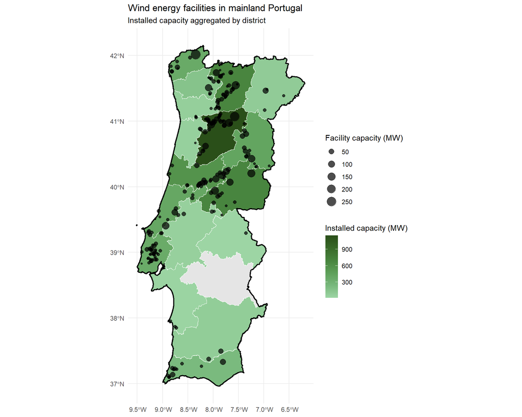

```r
map_facilities <- ggplot() +
  geom_sf(data = adm1_map,
    aes(fill = total_capacity_mw),
    color = "white",
    linewidth = 0.3) +
  geom_sf(data = e2p_pt,
    aes(size = potencia_instalada_mw),
    color = "black",
    alpha = 0.7) +
  geom_sf(data = adm0_pt,
    fill = NA,
    color = "black",
    linewidth = 0.8) +
  scale_fill_gradientn(colours = c(
      "#9dd5a4",
      "#78b87c",
      "#5ea059",
      "#48843e",
      "#396a29",
      "#2a4f19"),
    name = "Installed capacity (MW)",
    na.value = "grey90") +
  scale_size_continuous(name = "Facility capacity (MW)") +
  labs(title = "Wind energy facilities in mainland Portugal",
    subtitle = "Installed capacity aggregated by district",
    x = NULL,
    y = NULL) +
  theme_minimal()

print(map_facilities)
```

Figure 1: Map of the spatial distribution of wind energy facilities in mainland Portugal in relation to national and district boundaries. The map illustrates the geographic distribution and density of wind farms across districts.

# Question 2. Map the wind facilities and its distribution regarding elevation and protected areas. Find the the appropriate theme for the digital elevation model.

## 9. Digital Elevation Model

A 30 arc-second SRTM-derived digital elevation model was obtained using the `geodata` package and cropped to mainland Portugal.

```r
dem <- elevation_30s(country = "PRT",path = "data")

dem <- crop(dem,vect(adm0_pt))

dem <- mask(dem,vect(adm0_pt))
```

## DEM Visualization

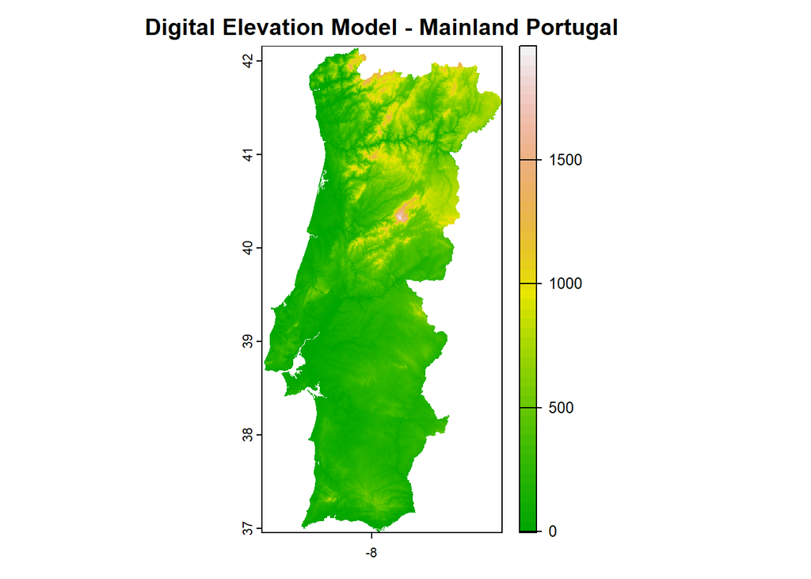

```r
plot(dem,  col = terrain.colors(50),
  main = "Digital Elevation Model - Mainland Portugal")
```

## 10. Elevation at Wind Facilities

Elevation values were extracted from the DEM at each wind facility

```r
e2p_pt$elevation_m <- terra::extract(dem, vect(e2p_pt))[, 2]
```

## Wind Facilities and Elevation

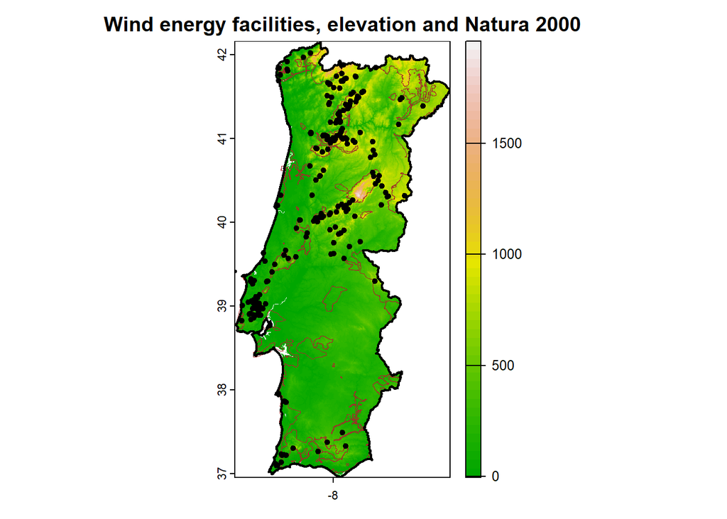

```r
plot(dem,  col = terrain.colors(50),
  main = "Wind energy facilities, elevation and Natura 2000")

plot(vect(rn2000),
  add = TRUE,
  border = "brown",
  col = NA,
  lwd = 0.8)

plot(vect(e2p_pt),
  add = TRUE,
  pch = 20,
  col = "black")

plot(vect(adm0_pt),
  add = TRUE,
  border = "black",
  lwd = 2)
```

Figure 2: Spatial overlay of wind energy facilities with topography (Digital Elevation Model) and protected areas within the Natura 2000 Network. The map highlights the intersection of 70 wind energy facilities with 13 distinct Natura 2000 sites across 11 mainland districts.

# Question 3. How are facilities distributed in relation to altitude? plot the attitudinal distribution and describe

## 11. Altitudinal Distribution

The altitudinal distribution of wind energy facilities was evaluated using a histogram and descriptive statistics.

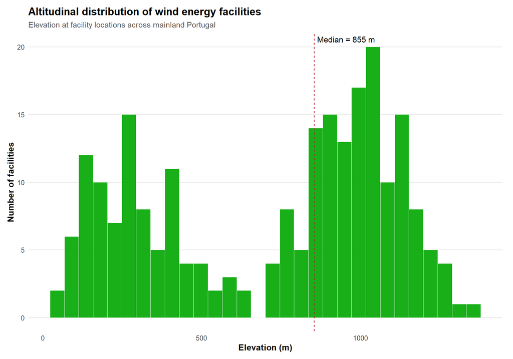

```r
elevation_plot <- ggplot(st_drop_geometry(e2p_pt),
  aes(x = elevation_m)) +
  geom_histogram(bins = 30,
    fill = "#00a600",
    color = "white",
    linewidth = 0.3,
    alpha = 0.9) +
  geom_vline(xintercept = median(e2p_pt$elevation_m,
      na.rm = TRUE),
    linetype = "dashed",
    linewidth = 0.4,
    color = "#B2182B") +
  annotate("text",
    x = median(e2p_pt$elevation_m,
      na.rm = TRUE),
    y = Inf,
    label = paste0("Median = ",
      round(median(e2p_pt$elevation_m,
          na.rm = TRUE),1)," m"),
    vjust = 1.5,
    hjust = -0.05,
    size = 4) +
  labs(title = "Altitudinal distribution of wind energy facilities",
    subtitle = "Elevation at facility locations across mainland Portugal",
    x = "Elevation (m)",
    y = "Number of facilities") +
  theme_minimal(
    base_size = 12) +
  theme(plot.title = element_text(
      face = "bold",
      size = 15),
    plot.subtitle = element_text(
      size = 11,
      color = "grey35"),
    axis.title = element_text(
      face = "bold"),
    panel.grid.minor = element_blank(),
    panel.grid.major.x = element_blank(),
    plot.margin = margin(10, 15, 10, 10))

print(elevation_plot)
```

Figure 3. Elevational distribution of wind energy facilities in mainland Portugal.

Wind energy facilities were distributed across a broad altitudinal range, from 29 to 1,340 m. The median elevation was 855 m, while the mean was 719 m. Half of the facilities were located between 322 and 1,034 m. The higher median than means suggests an asymmetric distribution, with a concentration of facilities at relatively high elevations and a smaller number occurring at lower elevations.

## Descriptive Statistics

```r
elevation_summary <- e2p_pt %>%
  st_drop_geometry() %>%
  summarise(
    n = n(),
    minimum = min(elevation_m, na.rm = TRUE),
    Q1 = quantile(elevation_m, 0.25, na.rm = TRUE),
    median = median(elevation_m, na.rm = TRUE),
    mean = mean(elevation_m, na.rm = TRUE),
    Q3 = quantile(elevation_m, 0.75, na.rm = TRUE),
    maximum = max(elevation_m, na.rm = TRUE)
)

elevation_summary
```

```
## # A tibble: 1 × 7
##       n minimum    Q1 median  mean    Q3 maximum
##   <int>   <dbl> <dbl>  <dbl> <dbl> <dbl>   <dbl>
## 1   235      29  322.    855  719. 1034.    1340
```

# Question 4. What was the total national installed capacity (in GW) in 2019?

## 12. Total Installed Capacity in 2019

The total installed wind energy capacity up to 2019 was calculated

```r
capacity_2019 <- e2p_pt %>%
  st_drop_geometry() %>%
  filter(ano_de_entrada_em_funcionamento <= 2019) %>%
  summarise(total_MW = sum(potencia_instalada_mw,
      na.rm = TRUE),
    total_GW = total_MW / 1000)

capacity_2019
```

```
## # A tibble: 1 × 2
##   total_MW total_GW
##      <dbl>    <dbl>
## 1    5367.     5.37
```

The total national installed wind energy capacity in mainland Portugal in 2019 was approximately 5.37 GW.

# Question 5. How has it grown (installed GW) since the first installed facility?

## 13. Growth of Installed Capacity

Annual and cumulative installed capacity were calculated according to the commissioning year of each facility

```r
capacity_growth <- e2p_pt %>%
  st_drop_geometry() %>%
  group_by(
    ano_de_entrada_em_funcionamento) %>%
  summarise(
    annual_MW = sum(potencia_instalada_mw,na.rm = TRUE),
    .groups = "drop") %>%
  arrange(ano_de_entrada_em_funcionamento) %>%
  mutate(cumulative_GW = cumsum(annual_MW) / 1000)

capacity_growth
```

```
## # A tibble: 24 × 3
##    ano_de_entrada_em_funcionamento annual_MW cumulative_GW
##    <chr>                               <dbl>         <dbl>
##  1 1992                                  1.8        0.0018
##  2 1996                                 10.2        0.012
##  3 1998                                 31.2        0.0432
##  4 1999                                 11.7        0.0549
##  5 2000                                 46.1        0.101
##  6 2001                                 40.4        0.141
##  7 2002                                 94.2        0.236
##  8 2003                                102.         0.337
##  9 2004                                335.         0.672
## 10 2005                                592.         1.26
## # ℹ 14 more rows
```

## Growth Plot

```
## `geom_line()`: Each group consists of only one observation.
## ℹ Do you need to adjust the group aesthetic?
```

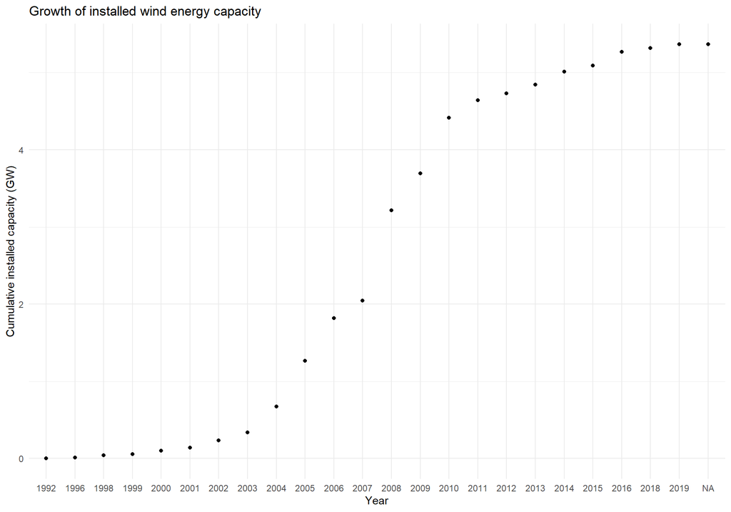

```r
growth_plot <- ggplot(capacity_growth,
  aes(x = ano_de_entrada_em_funcionamento,
    y = cumulative_GW)
) +
  geom_line(linewidth = 1) +
  geom_point() +
  labs(title = "Growth of installed wind energy capacity",
    x = "Year",
    y = "Cumulative installed capacity (GW)") +
  theme_minimal()

growth_plot
```

Figure 4. Temporal growth of cumulative installed wind energy capacity in mainland Portugal. The cumulative installed capacity reflects the progressive addition of wind energy facilities according to their commissioning year, expressed in gigawatts (GW).

## 14. Wind Facilities and Natura 2000

Wind facilities were spatially intersected with Natura 2000 sites

```r
e2p_natura <- st_join(e2p_pt,
  rn2000,
  join = st_intersects,
  left = FALSE)

n_facilities_natura <- nrow(e2p_natura)

n_facilities_natura
```

```
## [1] 70
```

## 15. Natura 2000 Sites Intersected

Distinct Natura 2000 sites intersected by wind facilities were identified

```r
intersected_sites <- e2p_natura %>%
  st_drop_geometry() %>%
  distinct(
    SITE_CODE,
    SITE_NAME,
    TIPO)

natura_sites_intersected <- nrow(intersected_sites)

intersected_sites
```

```
## # A tibble: 13 × 3
##    SITE_CODE SITE_NAME                         TIPO
##    <chr>     <chr>                             <chr>
##  1 PTCON0025 Montemuro                         SIC
##  2 PTCON0003 Alvâo/Marão                       SIC
##  3 PTCON0007 São Mamede                        SIC
##  4 PTCON0045 Sicó/Alvaiazere                   SIC
##  5 PTCON0039 Serra d'Arga                      SIC
##  6 PTCON0012 Costa Sudoeste                    SIC
##  7 PTCON0047 Serras de Freita e Arada          SIC
##  8 PTCON0015 Serras d'Aire e Candeeiros        SIC
##  9 PTCON0060 Serra da Lousã                    SIC
## 10 PTCON0037 Monchique                         SIC
## 11 PTCON0014 Serra da Estrela                  SIC
## 12 PTCON0004 Malcata                           SIC
## 13 PTCON0055 Dunas de Mira, Gândara e Gafanhas SIC
```

# Question 6. Are protected areas affected? Where and to which extent (number of Sites)?

## 16. Natura 2000 by District

The number of intersecting facilities and Natura 2000 sites was summarized by district

```r
natura_district <- st_join(e2p_natura,
  adm1_pt,
  join = st_within)

natura_by_district <- natura_district %>%
  st_drop_geometry() %>%
  group_by(Distrito) %>%
  summarise(intersected_facilities = n(),
    intersected_sites = n_distinct(SITE_CODE),
    .groups = "drop")

natura_by_district
```

```
## # A tibble: 11 × 3
##    Distrito         intersected_facilities intersected_sites
##    <chr>                             <int>             <int>
##  1 AVEIRO                                3                 2
##  2 CASTELO BRANCO                        1                 1
##  3 COIMBRA                               5                 2
##  4 FARO                                  6                 2
##  5 GUARDA                                3                 2
##  6 LEIRIA                                7                 3
##  7 PORTALEGRE                            1                 1
##  8 PORTO                                 4                 1
##  9 VIANA DO CASTELO                      2                 1
## 10 VILA REAL                            13                 1
## 11 VISEU                                25                 2
```

## 17. Wind Facilities and Natura 2000 Map

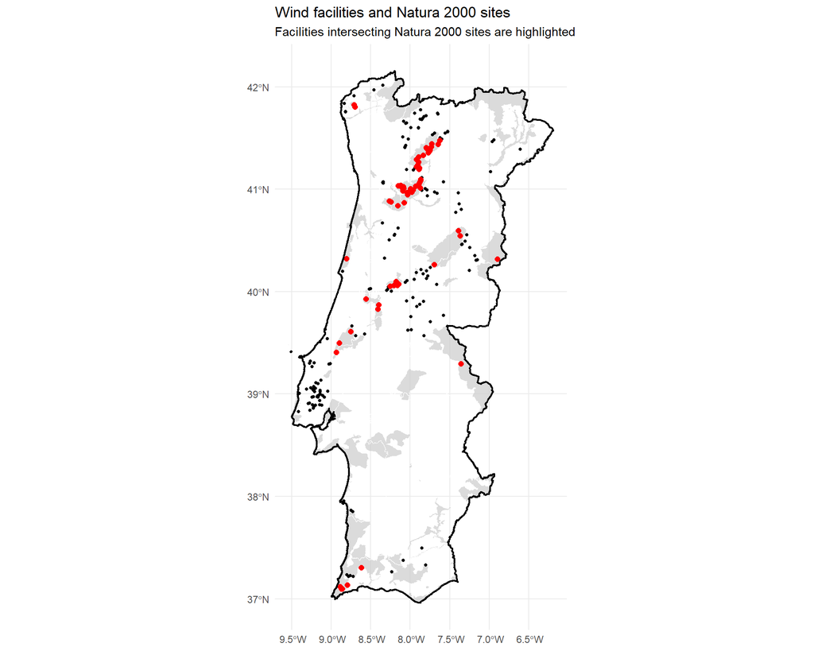

```r
map_natura <- ggplot() +
  geom_sf(data = rn2000,
    fill = "grey80",
    color = NA,
    alpha = 0.7) +
  geom_sf(data = adm1_pt,
    fill = NA,
    color = "white",
    linewidth = 0.3) +
  geom_sf(data = e2p_pt,
    color = "black",
    size = 1) +
  geom_sf(data = e2p_natura,
    color = "red",
    size = 2) +
  geom_sf(data = adm0_pt,
    fill = NA,
    color = "black",
    linewidth = 0.8) +
  labs(title = "Wind facilities and Natura 2000 sites",
    subtitle = "Facilities intersecting Natura 2000 sites are highlighted",
    x = NULL,
    y = NULL) +
  theme_minimal()

map_natura
```

Figure 5. Spatial distribution of wind energy facilities and Natura 2000 sites in mainland Portugal. Natura 2000 sites are shown in grey, while wind energy facilities are represented by black points. Facilities intersecting Natura 2000 sites are highlighted in red.

A total of 70 wind energy facilities intersect Natura 2000 protected areas, encompassing 13 distinct Natura 2000 sites across 11 mainland Portuguese districts. Viseu had the highest number of facilities intersecting protected areas (25), followed by Vila Real (13) and Leiria (7).

## 18. CHALLENGE: Interactive Map

An interactive map was created to allow inspection of individual wind facilities and their main attributes.

```r
e2p_leaflet <- st_transform(e2p_pt,4326)

# Creating an interactive map of wind energy facilities
interactive_map <- leaflet(e2p_leaflet) %>%
  addProviderTiles(providers$CartoDB.Positron) %>%
  addCircleMarkers(radius = 5,
    stroke = TRUE,
    fillOpacity = 0.8,
    popup = ~paste0("<b>Facility:</b> ",
      nome,"<br><b>Commissioning year:</b> ",
      ano_de_entrada_em_funcionamento,
      "<br><b>Installed capacity:</b> ",
      potencia_instalada_mw," MW"))

interactive_map
```

[interactive chart not shown]

Figure 6. Interactive map of wind energy facilities in mainland Portugal. Each point represents an individual wind facility, with pop-up information providing its name, commissioning year, and installed capacity.